# Office Mate Memo

#### **To: Quian Xu**

#### **From: Dani Alday, Joey Clancy**

#### **Date: 5/13/20**

#### **RE: Regarding Profitability for Office Mate**

Over the last decade, online shopping has overtaken general merchandise sales according to the US census bureau. Business practices that increased profitability in traditional brick and mortar shops may not be the most lucrative strategy in the digital markets. In a dataset of product sales between 2012 and 2015, we analyzed several variables including profit, revenue, discount levels, ship times, order dates, and others. We have concluded that the use of discounts should be applied more strategically. Our key findings were related to discount percentages and how much revenue and profit was brought in at each percentage. We found that most discounts above 20% brought in dramatically less revenue, and in most cases, negative profits (losses). Our analyses could provide a competitive edge over Amazon and other retailers. The corresponding suggestions to management and more detailed analyses are available below:

## Average Profit by Discount Availability:

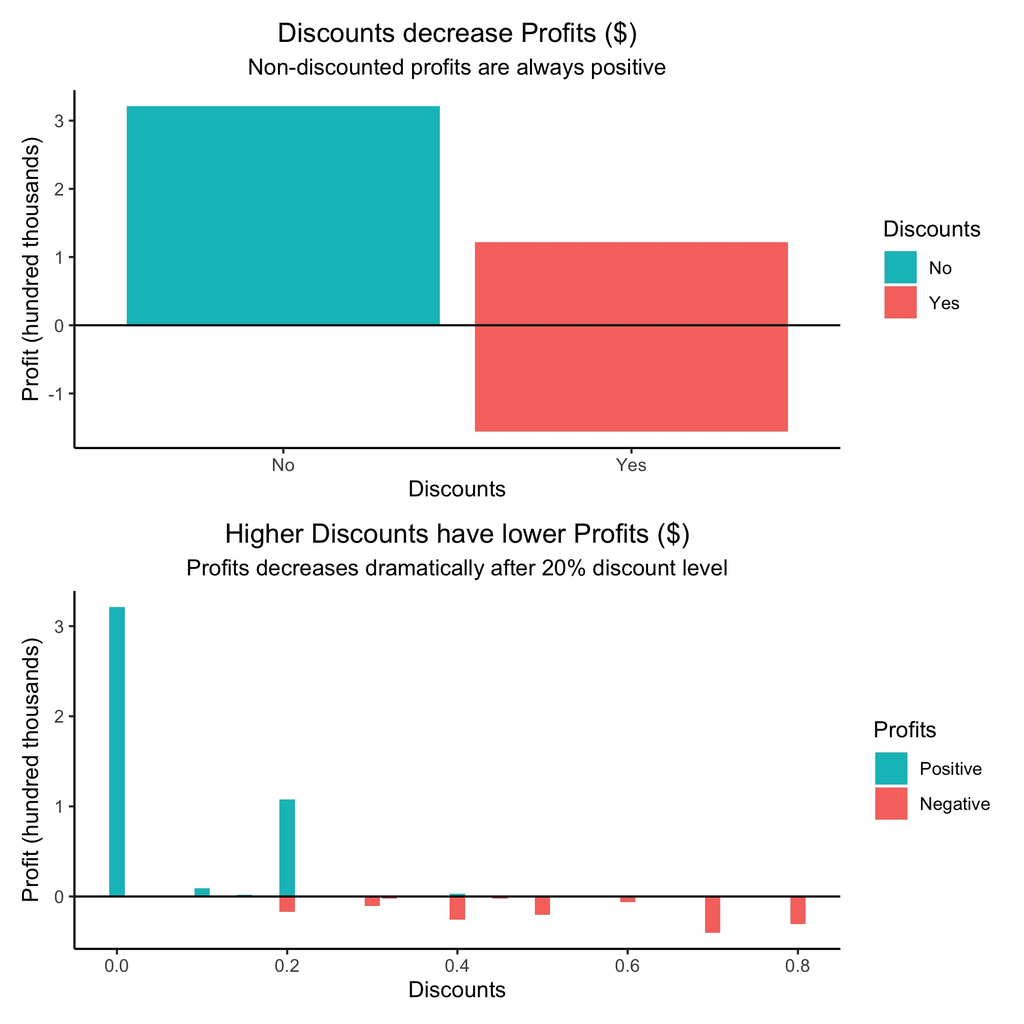

The graphs above are two visualizations of the same idea. We compared analyzed profit when discounts were given and not given in the top graph. We included a horizontal line that denotes the breakeven point (cost = revenue) for profit. Here, we see that if no discounts are given, profits will always be positive, with the highest profit at about $300,000. However, when discounts are given, we see a range where profits could be as high as $100,000 or as low as -$150,000. We did an additional breakdown in the second graph of how the percentage of discounts affect profits. This is shown in our second graph. When a discount is 20% or lower, we are more likely to have a positive profit, however when we increase discounts, our profits decrease. The lowest profit occurs when discounts are about 70%. With this finding, we recommend that for pure profitability, we should have discounts of less than 20%. However, we understand that discounts are a strategic tool to draw in new customers and increase revenue. This leads us to our second finding.